# Exploration_Hari

**Created by Hari** At 24 Feb 2024 03:00 AM

Bismillah

```python
from google.colab import drive
drive.mount('/content/drive')
```

```python
%cd /content/drive/My Drive/Colab Notebooks/RAKAMIN PERSONAL/learning/Homework Feature Extraction
```

```
/content/drive/My Drive/Colab Notebooks/RAKAMIN PERSONAL/learning/Homework Feature Extraction
```

```python
import warnings
warnings.filterwarnings('ignore')

import numpy as np
import pandas as pd
import seaborn as sns
import matplotlib.pyplot as plt
from scipy.stats import skew, kurtosis, stats
from collections import Counter
from sklearn.preprocessing import LabelEncoder
%matplotlib inline

# Package Information
print('numpy version : ',np.__version__)
print('pandas version : ',pd.__version__)
print('seaborn version : ',sns.__version__)
```

```
numpy version :  1.25.2
pandas version :  1.5.3
seaborn version :  0.13.1
```

```python
#Konstanta
sns.set(rc={'figure.figsize':(20.7,8.27)})
sns.set_style("whitegrid")
sns.color_palette("dark")
plt.style.use("fivethirtyeight")
```

# Load & Describe Data

**1. Gunakan function info dan describe pada dataset final project kalian. Tuliskan hasil observasinya, seperti :**

1. Apakah ada kolom dengan tipe data kurang sesuai, atau nama kolom dan isinya kurang sesuai? **Berdasarkan Explore Data nama kolom dan isi sudah sesuai**
2. Apakah ada kolom yang memiliki nilai kosong? Jika ada, apa saja? **category, rating, number_of_reviews, love, price, dan value_price.**
3. Apakah ada kolom yang memiliki nilai summary agak aneh? (min/mean/median/max/unique/top/freq) **terdapat feature yang memiliki nilai mean lebih tinggi dari median sehingga distribusi datanya menjadi codong ke kanan (positif) yaitu (number_of_reviews, love, price, value_price) selain itu terdapat feature yang berpotensi outlier karena nilai standar deviasi yang tinggi dan nilai maksimum yang jauh lebih tinggi dari kuartil ketiga yaitu (number_of_reviews, love, price, and value price)**

Untuk masing-masing jenis observasi, tuliskan juga jika tidak ada masalah, misal untuk A: “Semua tipe data sudah sesuai”

**Load Data**

```python
# Load datasets from csv files
dataset = pd.read_csv('Product_Exclusive_Classification.csv')
dataset = dataset.drop('id', axis=1) # Kolom id tidak relevan
```

**Datasets Information & Descriptive Statistic**

```python
# Explore Sample data
dataset.sample(10)
```

|  | brand | category | rating | number_of_reviews | love | price | value_price | exclusive |
| --- | --- | --- | --- | --- | --- | --- | --- | --- |
| 6030 | STELLAR | Face Primer | 4.0 | 11.0 | 2400.0 | 38.0 | 38.0 | 0 |
| 3819 | Moon Juice | Beauty Supplements | 4.0 | 69.0 | 6600.0 | 38.0 | 38.0 | 0 |
| 15 | CLINIQUE | Face Wash & Cleansers | 4.5 | 375.0 | 5400.0 | 15.5 | 15.5 | 0 |
| 7146 | Kérastase | Hair Masks | 5.0 | 6.0 | 1300.0 | 62.0 | 62.0 | 0 |
| 7279 | lululemon selfcare | Mini Size | 3.0 | 39.0 | 3300.0 | 12.0 | 12.0 | 0 |
| 5402 | Farmacy | Night Creams | 4.5 | 1000.0 | 110100.0 | 58.0 | 58.0 | 0 |
| 450 | Living Proof | Shampoo | 4.0 | 798.0 | 16900.0 | 28.0 | 28.0 | 0 |
| 1969 | Cinema Secrets | Face Primer | 3.5 | 69.0 | 7000.0 | 24.0 | 24.0 | 0 |
| 5215 | Dr. Jart+ | Face Masks | 4.0 | 45.0 | 8700.0 | 12.0 | 12.0 | 0 |
| 818 | SK-II | Sheet Masks | 4.5 | 380.0 | 49600.0 | 139.0 | 170.0 | 0 |

```python
# Info
dataset.info()
```

```
<class 'pandas.core.frame.DataFrame'>
RangeIndex: 8000 entries, 0 to 7999
Data columns (total 8 columns):
 #   Column             Non-Null Count  Dtype
---  ------             --------------  -----
 0   brand              8000 non-null   object
 1   category           7987 non-null   object
 2   rating             7905 non-null   float64
 3   number_of_reviews  7991 non-null   float64
 4   love               7966 non-null   float64
 5   price              7992 non-null   float64
 6   value_price        7983 non-null   float64
 7   exclusive          8000 non-null   int64
dtypes: float64(5), int64(1), object(2)
memory usage: 500.1+ KB
```

# Informasi Awal Dataset

Berikut adalah informasi yang mudah dibaca berdasarkan dataset yang diberikan:

1. Dataset ini terdiri dari 8000 data.
2. Feature yang tersedia id, brand, category, rating, number_of_reviews, love, price, value_price, dan exclusive.
3. Terdapat Missing Value pada feature : category, rating, number_of_reviews, love, price, dan value_price.

Hal yang akan dilakukan sebelum mengolah dataset adalah:

1. Menghapus kolom id karena tidak memiliki makna untuk dibuat statistik.
2. Treatment pada feature yang memiliki missing value.

```python
# Statistic Descriptive
dataset.describe()
```

|  | rating | number_of_reviews | love | price | value_price | exclusive |
| --- | --- | --- | --- | --- | --- | --- |
| count | 7905.000000 | 7991.000000 | 7.966000e+03 | 7992.000000 | 7983.000000 | 8000.000000 |
| mean | 4.085136 | 303.574396 | 1.756396e+04 | 49.900935 | 50.983300 | 0.255875 |
| std | 0.761069 | 931.724460 | 4.425339e+04 | 46.864764 | 48.473049 | 0.436379 |
| min | 0.000000 | 0.000000 | 0.000000e+00 | 2.000000 | 2.000000 | 0.000000 |
| 25% | 4.000000 | 14.000000 | 2.000000e+03 | 24.000000 | 24.000000 | 0.000000 |
| 50% | 4.000000 | 56.000000 | 5.500000e+03 | 35.000000 | 35.000000 | 0.000000 |
| 75% | 4.500000 | 231.500000 | 1.530000e+04 | 59.000000 | 60.000000 | 1.000000 |
| max | 5.000000 | 19000.000000 | 1.300000e+06 | 549.000000 | 549.000000 | 1.000000 |

**Analisa berdasarkan informasi Diatas**

Terdapat feature yang memiliki nilai mean lebih tinggi daripada median, berpotensi membuat distribusi datanya condong ke kanan (positif).

1. number_of_reviews: Mean: 303.574396, Median: 56.000000
2. love: Mean: 17563.96, Median: 5500.00
3. price: Mean: 49.90, Median: 35.00
4. value_price: Mean: 50.98, Median: 35.00

Feature yang mungkin terdapat outlier berdasarkan informasi diatas, nantinya akan dibuktikan dengan metode IQR:

**number_of_reviews, love, price & value price** analisa dilakukan dengan melihat nilai **standar deviasi yang tinggi dan nilai maksimum yang jauh lebih tinggi dari kuartil ketiga**

```python
# Memisahkan feature berdasarkan jenis
numerical_column = ['rating', 'number_of_reviews','love','price','value_price','exclusive']
categorical_column = ['brand', 'category']
```

```python
dataset[categorical_column].describe()
```

|  | brand | category |
| --- | --- | --- |
| count | 8000 | 7987 |
| unique | 310 | 142 |
| top | SEPHORA COLLECTION | Perfume |
| freq | 492 | 619 |

**Analias berdasarkan informasi statistik feature kategorikal**

Terlihat bahwa ada total **310 merek** yang berbeda dan **142 kategori** produk yang berbeda dalam dataset. **Merk yang paling sering muncul adalah "SEPHORA COLLECTION" dengan 492 data**, sementara **kategori produk yang paling umum adalah "Perfume" dengan 619 data**. Analisis ini memberikan gambaran tentang distribusi merek dan kategori produk dalam dataset, serta memberikan gambaran awal tentang tren atau preferensi konsumen yang mungkin tercermin dalam data tersebut.

# Exploratory Data Analysis (EDA)

**2. Univariate Analysis** Gunakan visualisasi untuk melihat distribusi masing-masing kolom (feature maupun target). Tuliskan hasil observasinya, misalnya jika ada suatu kolom yang distribusinya menarik (misal skewed, bimodal, ada outlier, ada nilai yang mendominasi, kategorinya terlalu banyak, dsb). Jelaskan juga apa yang harus di-follow up saat data pre-processing.

**Jawab** Terdapat outlier pada beberapa feature sehingga Distribusi tidak merata (detail ada di bawah) kami akan melakukan preprocessing untuk mengatasi masalah tersebut dengna berbagai teknik seperti normalisasi, transformasi, penghapusan outlier atau dengan memilih model yang tidak terpengaruh dengan data outlier

**Pendekatan Grafis**

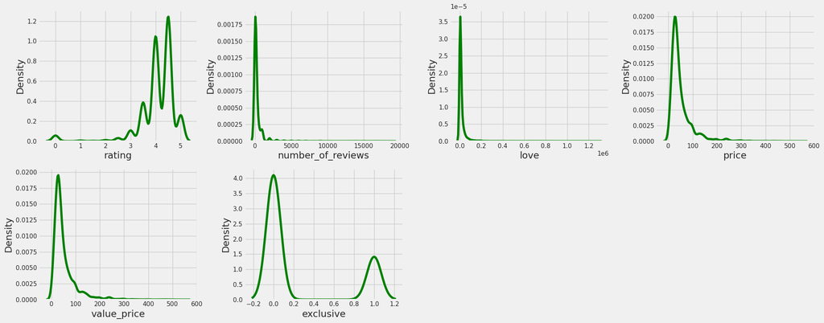

```python
# Analis Distribusi Data dengan KDE Plot
def print_kde(selected_dataset, features):
  for i in range(0, len(features)):
      plt.subplot(2, 4, i+1) # 2x4=8> len(numericals)=7
      sns.kdeplot(x=selected_dataset[features[i]], color='green')
      plt.xlabel(features[i])
      plt.tight_layout()

print_kde(dataset,numerical_column)
```

**Anlisa Distribusi setiap feature berdasarkan Grafik diatas**

Mayoritas data terkonsentrasi di sisi kanan dari nilai nol (Positif)

1. **Rating** distribusi terkonsentrasi pada sisi kanan, terdapat dua puncak kurva namun tidak sejajar. Akan lebih jelas apabila dicari tahu nilai skweness dan kurtosis nya

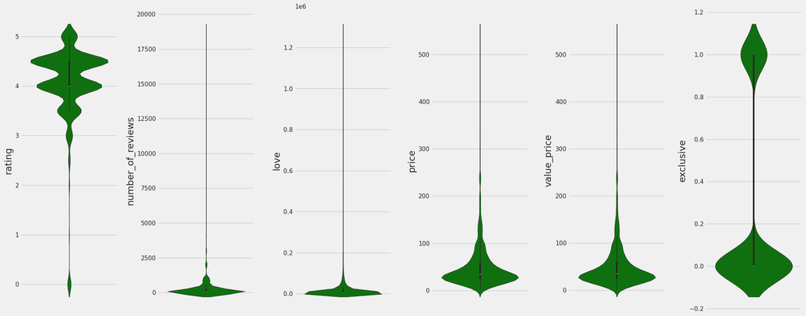

```python
#Individuals Violinplot
features = numerical_column
for i in range(0, len(features)):
  plt.subplot(1, len(features), i+1)
  sns.violinplot(y= dataset[features[i]], color='green', orient='v')
  plt.tight_layout()
```

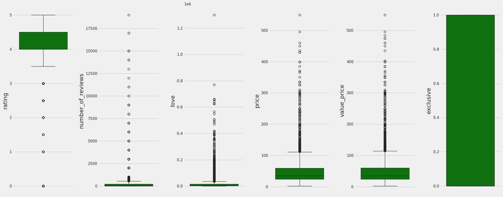

```python
#Individuals Boxplot
features = numerical_column
for i in range(0, len(features)):
  plt.subplot(1, len(features), i+1)
  sns.boxplot(y= dataset[features[i]], color='green', orient='v')
  plt.tight_layout()
```

Dari Boxplot diatas terlihat jelas bahwa Distribusi tidak merata dan terdapat outlier pada seluruh feature kecuali "exlclusive)

# 3. Multivariate Analysis

Lakukan multivariate analysis (seperti correlation heatmap dan category plots, sesuai yang diajarkan di kelas). Tuliskan hasil observasinya, seperti:

1. Bagaimana korelasi antara masing-masing feature dan label. Kira-kira feature mana saja yang paling relevan dan harus dipertahankan? **fitur yang paling relevan dan harus dipertahankan adalah value_price, karena memiliki korelasi yang paling tinggi dengan label (category_label), meskipun masih tergolong rendah. Namun, penting untuk dicatat bahwa semua korelasi cukup rendah, sehingga tidak ada fitur yang memiliki hubungan yang signifikan dengan label.**
2. Bagaimana korelasi antar-feature, apakah ada pola yang menarik? Apa yang perlu dilakukan terhadap feature itu? **mempertimbangkan untuk menghilangkan salah satu dari dua fitur yang redundan, yaitu Price atau Value_price. Selain itu, hubungan antara Love dan Number_of_reviews bisa dieksplorasi lebih lanjut untuk memahami faktor apa yang memengaruhi tingkat kepuasan dan jumlah ulasan pelanggan**

```python
#Korelasi Data Dengan Heatmap
label_encoder                     = LabelEncoder()
correlation                       = dataset[['brand','category','rating','love','price','value_price','exclusive','number_of_reviews']]
correlation['category_label']     = label_encoder.fit_transform(correlation['category'])
coor                              = correlation.corr()
coor
```

|  | rating | love | price | value_price | exclusive | number_of_reviews | category_label |
| --- | --- | --- | --- | --- | --- | --- | --- |
| rating | 1.000000 | 0.080472 | 0.053418 | 0.051654 | -0.015293 | 0.065639 | 0.008055 |
| love | 0.080472 | 1.000000 | -0.092059 | -0.091681 | 0.054244 | 0.744099 | -0.034745 |
| price | 0.053418 | -0.092059 | 1.000000 | 0.987777 | -0.184988 | -0.087781 | 0.057392 |
| value_price | 0.051654 | -0.091681 | 0.987777 | 1.000000 | -0.169355 | -0.090106 | 0.071657 |
| exclusive | -0.015293 | 0.054244 | -0.184988 | -0.169355 | 1.000000 | 0.005316 | 0.020060 |
| number_of_reviews | 0.065639 | 0.744099 | -0.087781 | -0.090106 | 0.005316 | 1.000000 | -0.014104 |
| category_label | 0.008055 | -0.034745 | 0.057392 | 0.071657 | 0.020060 | -0.014104 | 1.000000 |

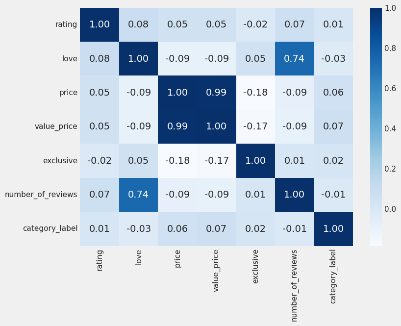

```python
plt.figure(figsize=(8, 6))
sns.heatmap(coor, cmap="Blues", annot=True, fmt='.2f')
plt.show()
```

Asumsi Label = Category Label (hasil label encoding dari feature category)

**Feature yagn relevan**

Berdasarkan korelasi tersebut, fitur yang paling relevan dan harus dipertahankan adalah value_price, karena memiliki korelasi yang paling tinggi dengan label (category_label), meskipun masih tergolong rendah. Namun, penting untuk dicatat bahwa semua korelasi cukup rendah, sehingga tidak ada fitur yang memiliki hubungan yang signifikan dengan label.

**Pola Fitur yang menarik**

**Price dan Value_price memiliki korelasi yang sangat tinggi (0.987777)**, yang menunjukkan bahwa keduanya hampir identik atau sangat mirip dalam hal korelasi dengan fitur lainnya. mungkin perlu untuk mempertimbangkan untuk menggunakan hanya salah satu dari kedua fitur ini dalam analisis lebih lanjut.

**Love memiliki korelasi yang cukup tinggi dengan Number_of_reviews (0.744099)**, menunjukkan bahwa produk dengan tingkat kepuasan yang tinggi cenderung memiliki lebih banyak ulasan. Pola ini bisa dijelaskan dengan asumsi bahwa produk yang disukai cenderung menarik lebih banyak perhatian dan ulasan dari konsumen.